# Laboratorio 1- Bonus track Análisis estadístico de datos extremales

### Carolina Crisci, Gonzalo Perera, Angel Segura

# Introducción

En este *bonus track* veremos en detalle los ajustes de diferentes distribuciones extremales y como evaluar cual es mejor con dos métodos, la razon de verosimilitudes (LRT por sus siglas en inglés) y un test de Kolmogorov-Smirnof cuando conocemos los parámetros teóricos de la población del cual surgen los máximos. Además veremos como estimar el intervalo de confianza del índice de una GEV de forma automática. Recordemos que el indice ($\xi$) es el que define la forma de la distribución y que cuando el IdC incluye el cero, entonces la GEV es una distribución de Gumbel.

El ejercicio lo haremos en base a la simulación normal del LAB1 de la distribución Normal.

Como moraleja, recordemos que en algunos casos puede haber ajustes aceptables a más de una distribución, y que **siempre** es la investigadora o el investigador que tiene que resolver cual utilizar para estimar por ejemplo los tiempos de retorno. Recuerden el compromiso entre costo y seguridad.

## NORMAL

Dado datos $X_1, ..., X_n$ *iid* con distribución $F$, en este caso $F$ es la distribucion Normal o Gaussiana. Entonces $X^*_n = max(X_1, ...,X_n)$ tiene una distribución $F^*_n$ dada por $F_n^*(t)=F(t)^n$. Tal como se presenta en el teórico, si conocemos la distribución $F$ conoceríamos la distribución $F^*_n$. En la vida real pocas veces conocemos la distribución generadora, pero en este LAB si la conocemos y podemos hacer el ejercicio de derivar los parámetros de la distribución esperada ($F^*_n$).

Recordemos que del teorema de Fischer-Tippet-Gnedenko (FTG) los maximos de una distribución tienden a una de las tres distribuciones extremales (Weibull, Gumbel, Frechet). Sabemos que las distribuciones que admiten DEA ($H$) son aquellas en las cuales existen dos sucesiones de números reales ($d_n ~y~ c_n$) tal que ${max(X_1,...,X_n)- d_n \over c_n} \to H~~cuando~~ n \to \infty$.

Estas series, son función del número de muestras que incluyo en cada bloque del cual extraigo el máximo. Esto es razonable, y pongamos un ejemplo (tomado prestado de https://blogs.sas.com/content/iml/2019/07/22/extreme-value-normal-data.html) con la distribución Normal para verlo de forma intuitiva. Si tomamos 10 valores aleatorios de una distribución Normal estandar, es extremadamente poco probable que el valor máximo sea mayor a 4. Recuerden que el 99.7% de los valores estará dentro de 3 desvios estándard de la media. Pero poco probable no significa 0. Si en lugar de 10 valores tomamos 10 millones de valores, probablemente alguno este por encima de 4. Por lo tanto, la distribución extremal asintótica necesariamente depende de la cantidad de datos de la cual se extrae el máximo.

```r
# Esta es una forma de evaluar si algún valor está por encima de 4 de una normal estandar aleatoria
any(rnorm(10)>4)
```

```
## [1] FALSE
```

```r
any(rnorm(10e6)>4)
```

```
## [1] TRUE
```

Cuando la distribución es una Normal, siguiendo la derivación en Embrechts et al 2012 (pg 147 (eq. 3.40)) para una Normal estandar ($\mu=0;~ \sigma=1$) se deriva que las series $a_n ~y~ c_n$ son:

$d_n= \sqrt{(2*log(n))} ~-~ {log~(log(n)) +log(4\pi) \over 2 \sqrt{(2 log(n)}}$ y

$c_n= (2 ~log(n))^{-1/2}$

Definamos una función de **R** para calcular $a_n ~y~ c_n$ y grafiquemos como varían según el tamaño de la muestra $n$.

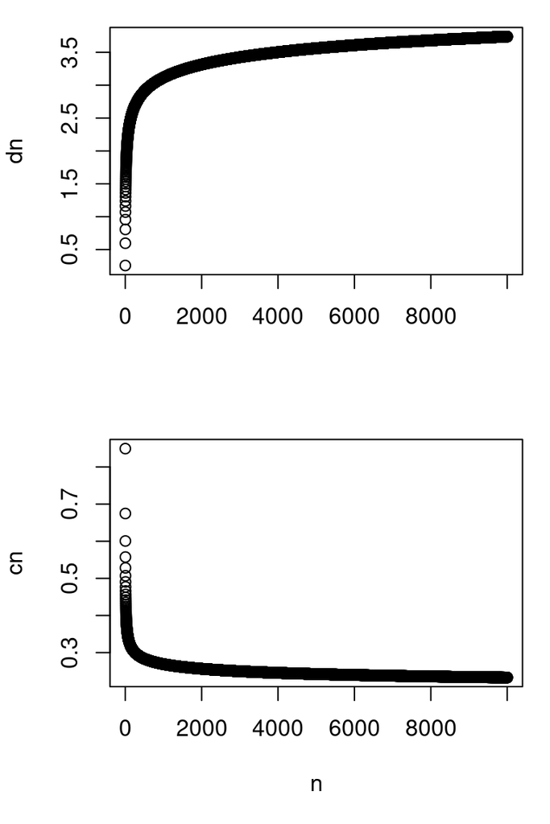

```r
# Esa serie varía con n, pero en nuestro caso, cuando fijo n (que es el N del numero de normales de las cuales extraigo el maximo), cn es beta y dn es un número
dn_cn_funNormal<-function(N){
n_aux<-N
firstTerm<- sqrt(2*log(n_aux))
secondTerm<- ((log(log(n_aux)) + log(4*pi))) / (2*sqrt(2*log(n_aux)))

dn<- firstTerm - secondTerm

cn <- (2*log(n_aux))^(-1/2)
list(cn=cn, dn=dn)
}

par(mfrow=c(2,1), mar=c(5,4,1,1))
plot(1:10000, dn_cn_funNormal(1:10000)$dn, ylab="dn", xlab="")
plot(1:10000, dn_cn_funNormal(1:10000)$cn, ylab="cn", xlab="n")
```

En el caso de la Normal estandar, sabemos que esta serie tiene como DEA la Gumbel ($\Lambda$), por lo tanto, los máximos tomados de $n$ distribuciones Normal estandard ($X^*$) siguen que:

$${(X^*_1, ...,X^*_n) - d_n \over c_n} \to \Lambda$$

En el caso que la Normal no sea estandar, es decir ($\mu \ne 0 ~y~ \sigma \ne 1$) debemos tipificar la variable de máximos previo al cálculo. De forma general, podemos decir que una variable Normal($\mu,~\sigma$) tiene:
$${({(X^*_1, ...,X^*_n)-\mu \over \sigma}) - d_n \over c_n} \to \Lambda$$
De esta manera podemos obtener los parámetros teóricos esperables de una $\Lambda^{\alpha,\beta}$ (siguiendo la nomenclatura del teórico), que son: $\alpha= d_n \sigma + \mu \\ \beta= c_n \sigma$

Como se aprecia los mismos son función de los parámetros originales y del número de datos del cual se extraen los máximos.

Veamos un ejemplo concreto para fijar conceptos y aplicar algunos test para evaluar entre modelos competidores.

```r
require(evd)
require(extRemes)
```

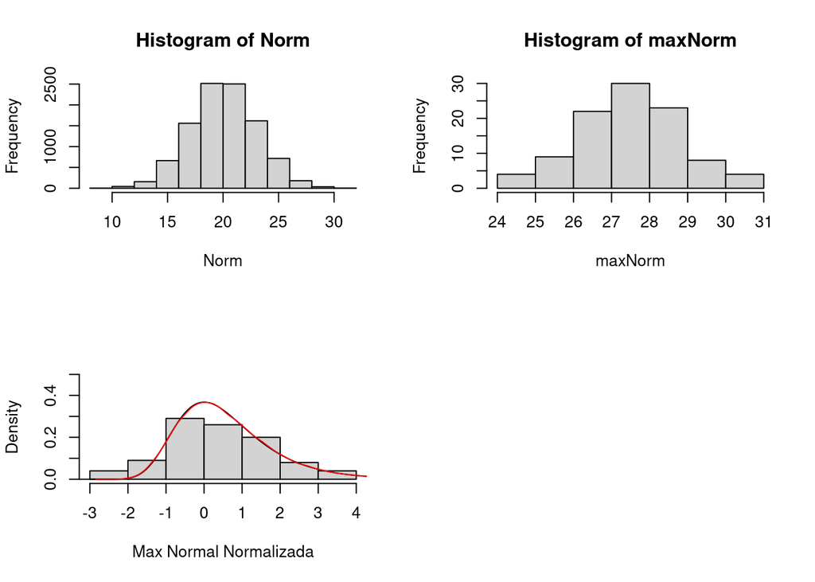

```r
set.seed(32)
Nnorm<-10000 # numero de valores totales a simular
muNorm<- 20 # Valor de la media de la normal
sigmaNorm<- 3 # Valor del desvío de la distribución a simular

Norm<-rnorm(Nnorm, muNorm, sigmaNorm)

hist(Norm)

# Tomemos los maximos de periodos de Nbins registros cada uno (esto indica el numero de datos por bloque a usar)
Nbins<-100
selPeriodo<-as.factor(rep(1:(Nnorm/Nbins), each=Nbins))
maxNorm<-unlist(lapply( split(Norm, selPeriodo), max))


# El N efectivo es el del tamaño de los Bins que uso para estimar el maximo.
# Si la media de la normal generadora es diferente de 0, debo restar la media al valor
par(mfrow=c(2,2))
hist(Norm)
hist(maxNorm)

hist((((maxNorm- muNorm)/sigmaNorm) - (dn_cn_funNormal(Nbins)$dn) ) / (dn_cn_funNormal(Nbins)$cn), prob=TRUE, main="", xlab="Max Normal Normalizada", yli=c(0,0.5))
lines(seq(-6,6, length=1000), dgumbel(seq(-6,6, length=1000))) # la Gumbel estandar teórica
lines(density(rgumbel(100000)), col="red") # una simulacion de 10000 datos de una Gumbel estandar
```

```r
# AJUSTAMOS UNA DISTRIBUCIÓN Extrmal Generalizada por maxima verosimilitud (MLE)
modNorm<-fevd(maxNorm, method="MLE")

# Estimamos el intervalo de confianza del índice (which.par=3)
ci.fevd(modNorm, type = "parameter", which.par = 3, nint = 100, method = "proflik", verbose = TRUE)
```

```
##
##  Preparing to calculate  95 % CI for  shape parameter
##
##  Model is   fixed
##
##  Using Profile Likelihood Method.
##
##  Calculating profile likelihood.  This may take a few moments.
```

```
##
##  Using a range of  -1.734178  to  1.040507
```

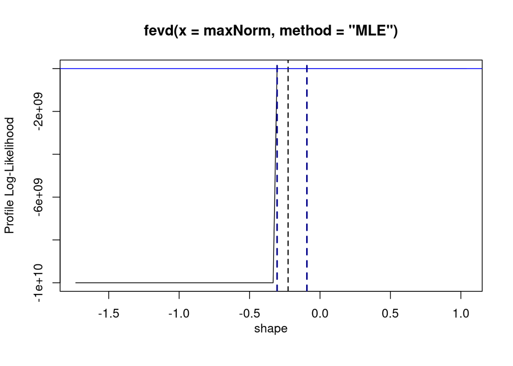

```
##
##  Profile likelihood has been calculated.  Now, trying to find where it crosses the critical value =  -170.0919
```

```
## fevd(x = maxNorm, method = "MLE")
##
## [1] "Profile Likelihood"
##
## [1] "shape: -0.227"
##
## [1] "95% Confidence Interval: (-0.3048, -0.0931)"
```

Vemos que a pesar que debería sugerirnos una distribución Gumbell, el indice ($\xi<0$) lo que sugiere una distribución acotada de Weibull.

```r
# AJUSTAMOS UNA DISTRIBUCIÓN Gumbel por maxima verosimilitud (MLE)
modNormGumbel<-fevd(maxNorm, method="MLE", type="Gumbel")

lr.test(modNorm, modNormGumbel)
```

```
##
##  Likelihood-ratio Test
##
## data:  maxNormmaxNorm
## Likelihood-ratio = 9.6148, chi-square critical value = 3.8415, alpha =
## 0.0500, Degrees of Freedom = 1.0000, p-value = 0.00193
## alternative hypothesis: greater
```

```r
require(reliaR)
# hagamos un test del test, para ver como funciona con una distribución que sabemos que es Gumbel
GumbelSimulada<-rgumbel(1000, mu=3, sigma=2)
ks.gumbel(GumbelSimulada, mu.est=3, sigma.est=2, alternative="two.sided")
```

```
##
##  One-sample Kolmogorov-Smirnov test
##
## data:  x
## D = 0.031998, p-value = 0.2575
## alternative hypothesis: two-sided
```

Vemos que no rechazamos la $H_0$, o sea que la distribución es una Gumbel. Ahora hagamos el test sobre nuestros datos simulados tomados a partir de distribuciones normales y en base a estimar los parámetros con las fórmulas teóricas que vimos arriba.

```r
# Estimemos los parámetros de la Gumbel teóricos
alpha<- dn_cn_funNormal(Nbins)$dn * sigmaNorm + muNorm
beta<- dn_cn_funNormal(Nbins)$cn * sigmaNorm
ks.gumbel(maxNorm, mu.est=alpha, sigma.est = beta, alternative="two.sided")
```

```
##
##  One-sample Kolmogorov-Smirnov test
##
## data:  x
## D = 0.088731, p-value = 0.4105
## alternative hypothesis: two-sided
```

No podemos rechazar la $H_0$ de Gumbel. Esto es importante, por que nos cuestiona nuevamente la posibilidad de que esa sea una representación adecuada de los datos.

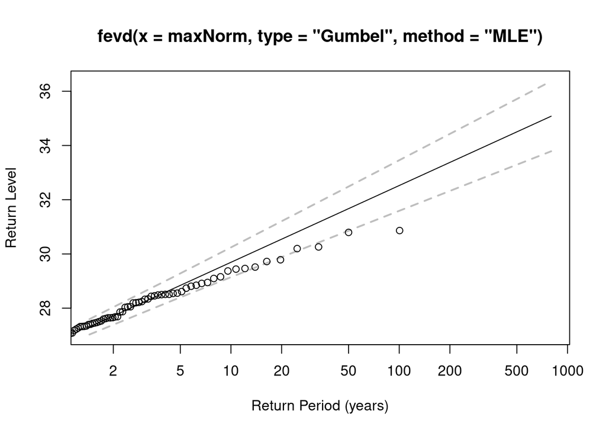

```r
plot(modNormGumbel, type="rl")
```

Comparemos aquí los tiempos de retorno estimados a partir del ajuste a una distribución de Gumbel y una Weibull

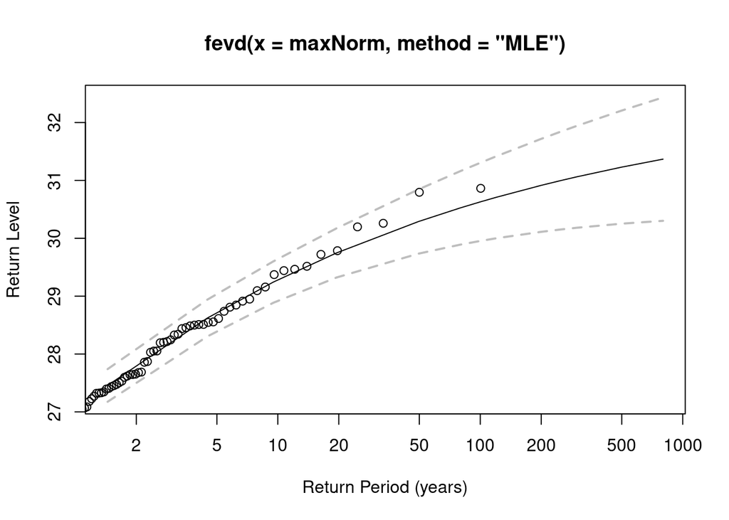

```r
plot(modNorm, type="rl")
```

Notemos que, como es de esperar, los niveles de retorno quedan por debajo del valor esperado (línea continua) en valores altos en el caso de la Gumbel y quedan por encima en el caso de la Weibull. Particularmente, estos casos de doble ajuste, requieren del criterio de la investigadora o el investigador para definir la aproximación. El fenómeno que se esté modelando es sumamente relevante para definir la aproximación a utilizar. Si bien este es un caso paradigmático, este principio de las decisiones humanas/políticas deben siempre prevalecer y no ser escondidas detras de tecnisismos.

### Bibliografía

Paul Embrechts, Claudia Klüppelberg, Thomas Mikosch 2012. Modelling Extremal Events for Insurance and Finance. 4ta Edición. ISBN 978-3-642-08242-9. DOI 10.1007/978-3-642-33483-2